# Exploration des données

# Extraction

Préparation d’un dataframe qui servira à créer les jeux de points pour l’analyse spatiale.

```r
les_arbres@data %>%
  # Ajout des colonnes de coordonnées
  bind_cols(as.data.frame(les_arbres_Lambert93@coords)) %>%
  # Sélection des colonnes
  select(-typeemplacement, -geo_point_2d1, -geo_point_2d2, -complementadresse) %>%
  # Filtrage des lignes
  dplyr::filter(str_detect(arrondissement, "^PARIS")) %>%
  # Ajout d'une colonne Genre espèce
  mutate(spName=paste(genre, espece)) ->
  les_arbres_df
```

# Espèces

```r
library("entropart")
les_arbres_df %>%
  group_by(spName) %>%
  summarise(Nombre=n()) %>%
  arrange(desc(Nombre)) ->
  AbdFreqCount
```

Espèces les plus fréquentes :

```r
AbdFreqCount
```

```
## # A tibble: 633 x 2
##    spName                 Nombre
##    <chr>                   <int>
##  1 Platanus x hispanica    33303
##  2 Aesculus hippocastanum  15507
##  3 Sophora japonica        10714
##  4 Tilia tomentosa          6987
##  5 Acer platanoides         4423
##  6 Acer pseudoplatanus      4418
##  7 Aesculus x carnea        4013
##  8 Celtis australis         3492
##  9 Tilia x europaea         3465
## 10 Platanus occidentalis    3221
## # ... with 623 more rows
```

Fréquence des espèces :

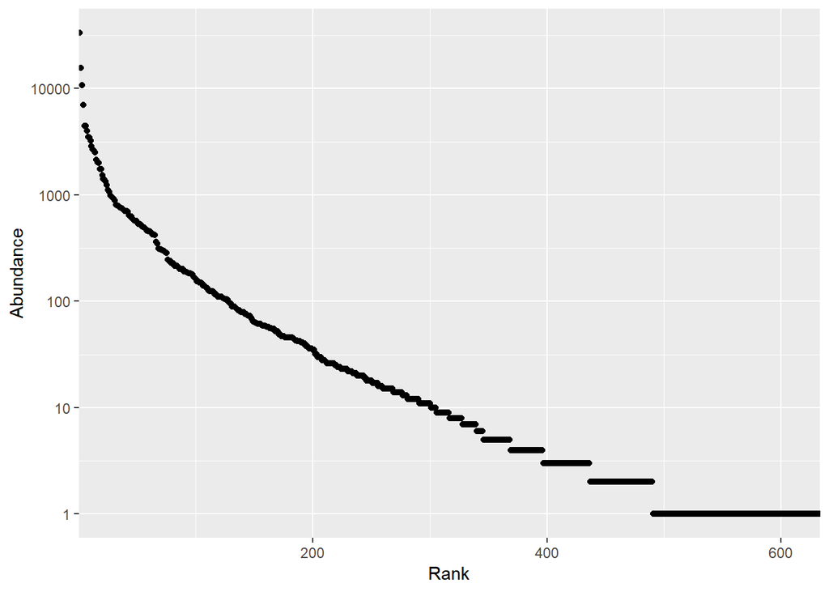

```r
AbdFreqCount %>%
  with(Nombre) %>%
  as.AbdVector %>%
  autoplot
```

# Diversité

## Par domanialité

```r
library("SpatDiv")
les_arbres_df %>%
  group_by(domanialite, arrondissement, adresse) %>%
  summarise(Nombre = length(adresse),
            Richesse = Richness(spName, Correction="None"),
            Shannon = Diversity(spName, q=1, Correction="None"),
            Simpson = Diversity(spName, q=2, Correction="None")) %>%
  arrange(desc(Richesse)) ->
  Diversite
```

Les alignements sont très peu divers, à l’exception de l’Allée des Cygnes qui est un arboretum.

```r
# Diversite[Diversite$adresse=="ALLEE DES CYGNES", ]$domanialite <- "Jardin"
Diversite %>%
  group_by(domanialite) %>%
  summarise(Nombre = n(),
            Moyenne = mean(Richesse),
            EcartType = sd(Richesse))
```

```
## # A tibble: 9 x 4
##   domanialite  Nombre Moyenne EcartType
##   <fct>         <int>   <dbl>     <dbl>
## 1 Alignement     1977    2.29      2.60
## 2 CIMETIERE       760    2.76      2.74
## 3 DAC               6    2.33      1.86
## 4 DASCO           669    3.85      3.01
## 5 DASES             1    1       NaN
## 6 DFPE            244    3.11      2.53
## 7 DJS             101    9.67     10.00
## 8 Jardin          695   11.1      20.0
## 9 PERIPHERIQUE    204    5.25      5.01
```

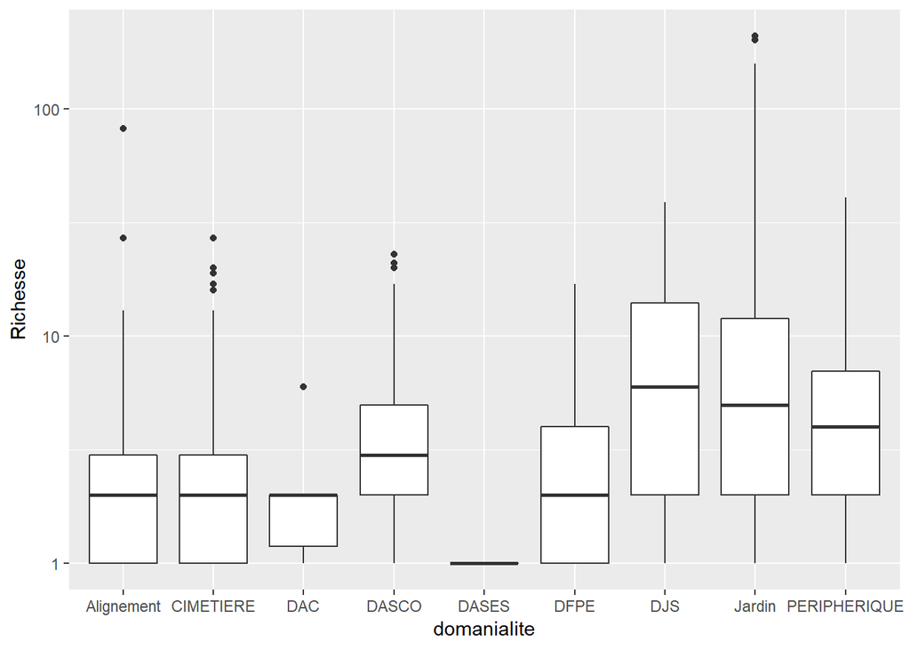

```r
Diversite %>%
  ggplot(aes(x=domanialite, y=Richesse)) +
  geom_boxplot() +
  scale_y_continuous(trans = "log10")
```

# Diversité spatialement explicite

Automatisation de la création des jeux de points.

```r
library("dbmss")
# Extraction of a wmppp from an address
wmppp_adresse <- function(address, alpha=100, reverse=FALSE) {
  # Prepare the dataframe
  les_arbres_df %>%
    filter(adresse == address) %>%
    mutate(X=coords.x1, Y=coords.x2,
           PointType=spName, PointWeight=circonferenceencm) ->
    Points
  # Window = Convex hull
  #Window <- convexhull.xy(Points$X, Points$Y)
  # Window = alpha shape, i.e. concave hull
  Points %>%
    select(x=X, y=Y) %>%
    # Package alphahull
    alphahull::ashape(alpha=alpha) ->
    AlphaShape
  # Convert alpha shape into polygon (https://rpubs.com/geospacedman/alphasimple)
  library("igraph")
  # Make a graph with edges
  AlphaShape_graph <- graph.edgelist(cbind(as.character(AlphaShape$edges[, "ind1"]),
                                           as.character(AlphaShape$edges[, "ind2"])), directed = FALSE)
  # Tests: the graph must be connected and circular. If it is not, increase alpha.
  if (!is.connected(AlphaShape_graph)) {
    stop("Graph not connected")
  }
  if (any(degree(AlphaShape_graph) != 2)) {
    stop("Graph not circular")
  }
  if (clusters(AlphaShape_graph)$no > 1) {
    stop("Graph composed of more than one circle")
  }
  # Eliminate the first node to destroy circularity
  Cut_graph <- AlphaShape_graph - E(AlphaShape_graph)[1]
  # Find chain end points
  ends <- names(which(degree(Cut_graph) == 1))
  path <- get.shortest.paths(Cut_graph, ends[1], ends[2])[[1]]
  # This is an index into the points
  pathX <- as.numeric(V(Cut_graph)[unlist(path)]$name)
  # Detach igraph to avoid name conflicts
  detach("package:igraph", unload=TRUE)
  # Join the ends to restore circularity
  pathX = c(pathX, pathX[1])
  # Get the points from the ashape object.
  if (reverse) {
    # Reverse order to have the anticlockwise for spatstat.
    Poly_summmits <- AlphaShape$x[rev(pathX), ]
  } else {
    Poly_summmits <- AlphaShape$x[pathX, ]
  }
  # Make an owin
  Window <- owin(poly=list(x=Poly_summmits[, 1],y=Poly_summmits[, 2]))
  # Create the point set
  Points %>%
    wmppp(window = Window, unitname = c("meter", "meters"))
}
```

## Dans les parcs

Les deux parcs les plus peuplés sont Les Buttes Chaumont et André Citröen avec un peu plus de 2000 arbres.

```r
Diversite %>%
  dplyr::filter(Nombre > 2000) %>%
  knitr::kable(caption="Parcs les plus peuplés", longtable = TRUE, booktabs = TRUE) %>%
  kableExtra::kable_styling(bootstrap_options = "striped", full_width = FALSE)
```

Parcs les plus peuplés

| domanialite | arrondissement | adresse | Nombre | Richesse | Shannon | Simpson |
| --- | --- | --- | --- | --- | --- | --- |
| Jardin | PARIS 19E ARRDT | PARC DES BUTTES CHAUMONT | 2319 | 135 | 27.11576 | 11.58703 |
| Jardin | PARIS 15E ARRDT | PARC ANDRE CITROEN | 2083 | 70 | 25.61172 | 11.03714 |

Le Parc des Buttes Chaumont contient énormément d’espèces mais beaucoup d’espèces rares.

```r
Buttes_Chaumont <- wmppp_adresse("PARC DES BUTTES CHAUMONT",
    reverse = TRUE)
```

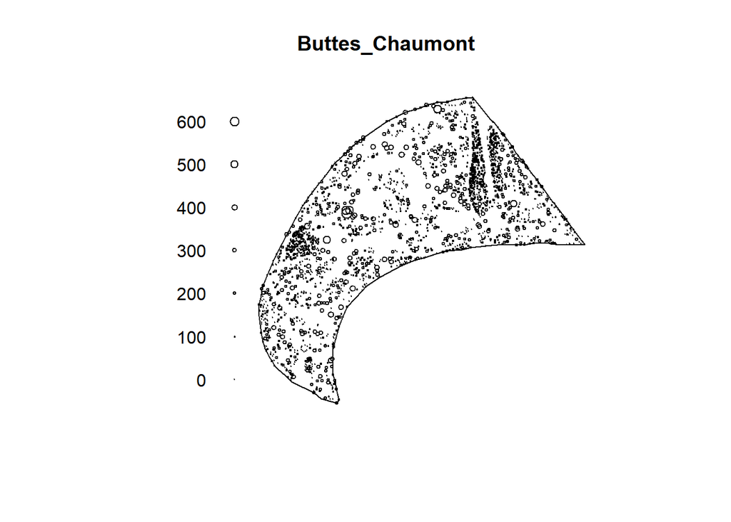

```r
plot(Buttes_Chaumont, which.marks = "PointWeight")
```

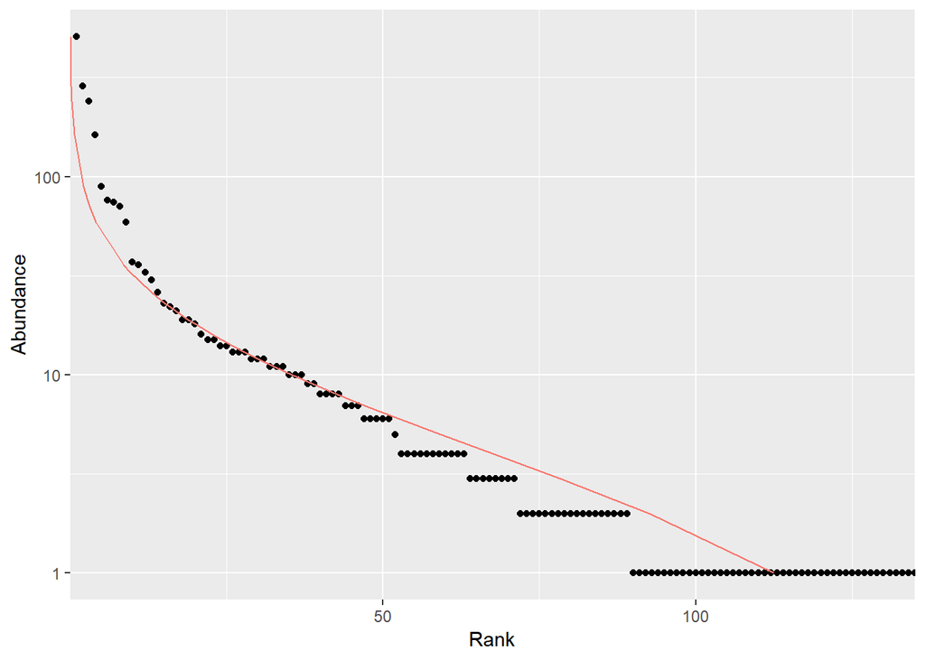

```r
autoplot(as.AbdVector(Buttes_Chaumont), Distribution = "lnorm")
```

```r
Buttes_Chaumont_accum <- Mixing(Buttes_Chaumont, q.seq = c(0,
    2), Individual = TRUE)
```

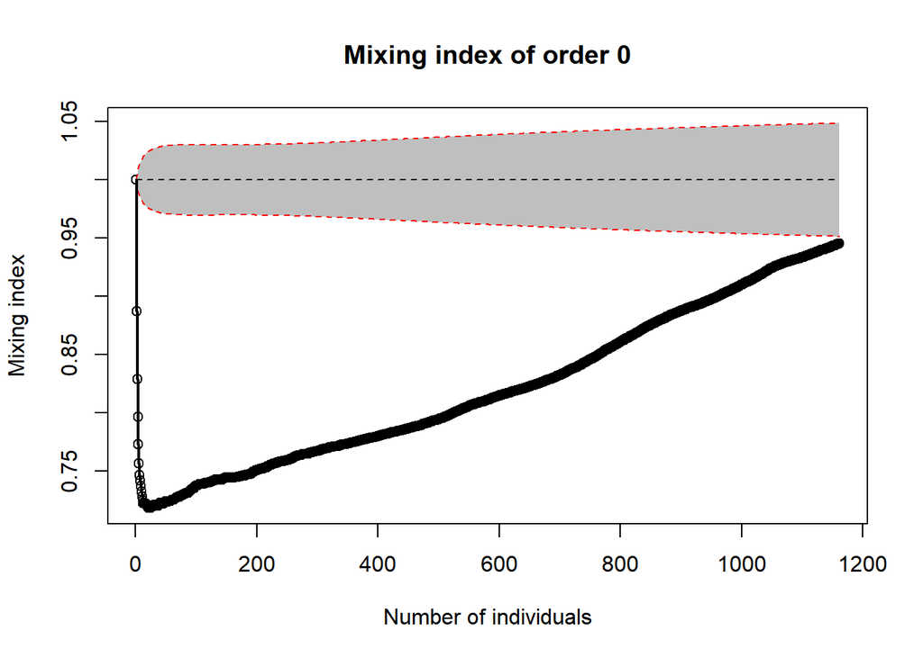

```r
plot(Buttes_Chaumont_accum, q = 0)
```

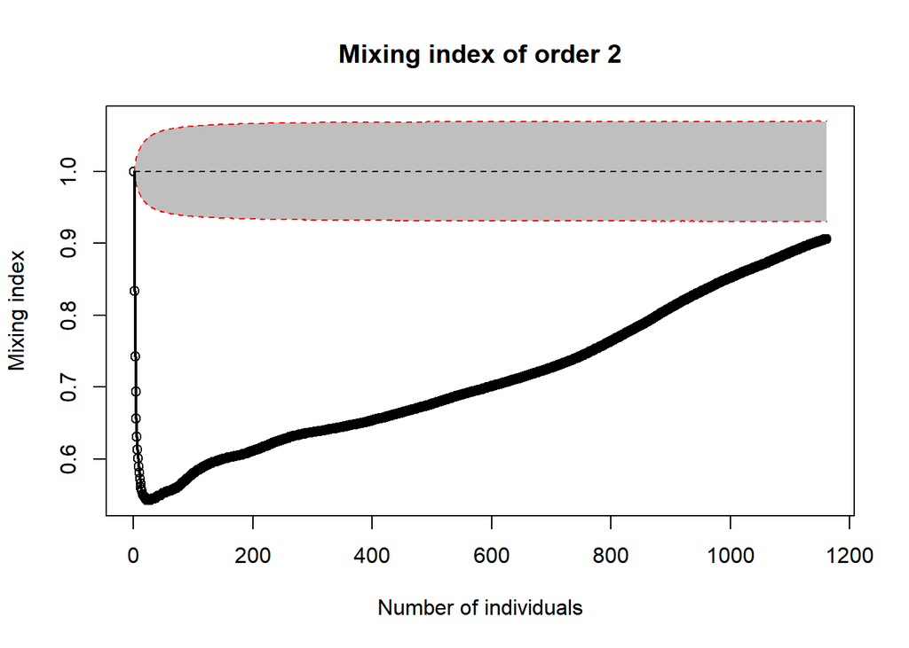

```r
plot(Buttes_Chaumont_accum, q = 2)
```

```
## [using ordinary kriging]
```

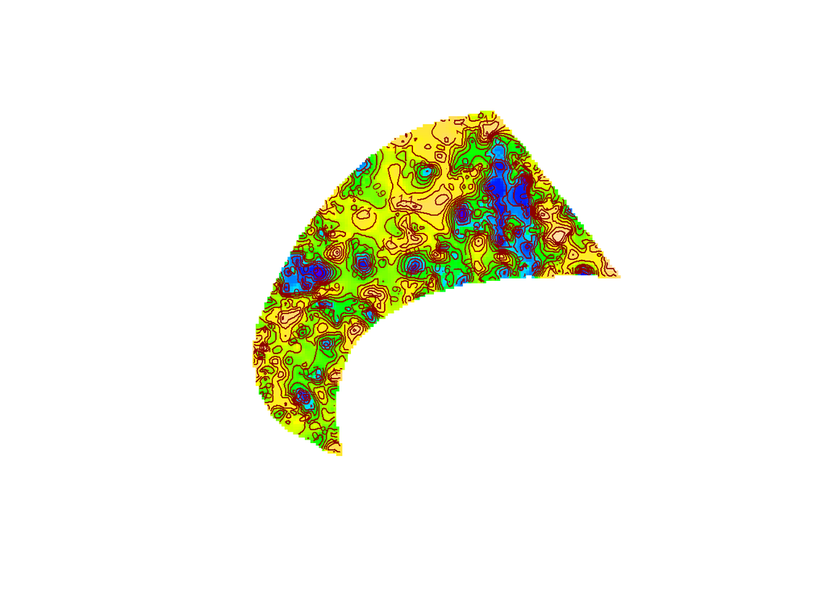

```r
MapPlot(Buttes_Chaumont_accum, Order = 0, NeighborHood = 10)
```

Le Parc Montceau contient 20 espèces de plus mais est 5 fois plus divers à l’ordre 2.

```r
Montceau <- wmppp_adresse("PARC MONCEAU")
```

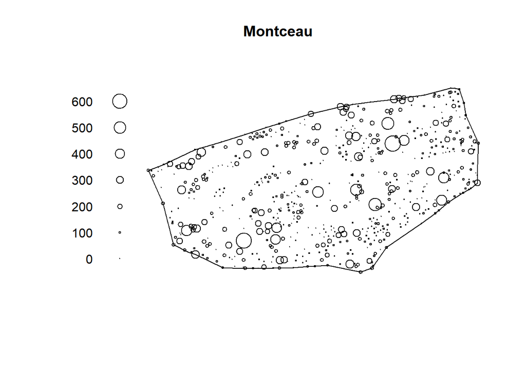

```r
plot(Montceau, which.marks = "PointWeight")
```

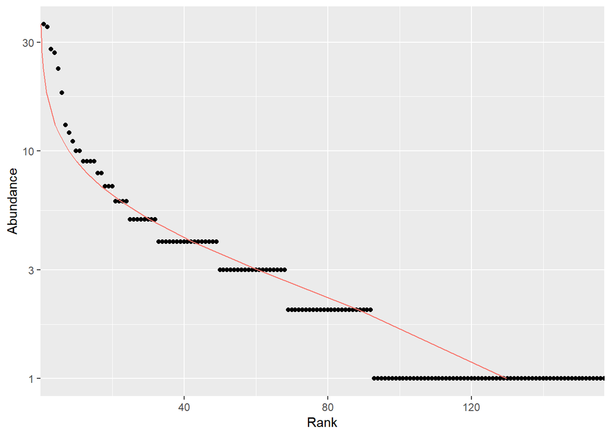

```r
autoplot(as.AbdVector(Montceau), Distribution = "lnorm")
```

```r
Montceau_accum <- Mixing(Montceau, q.seq = c(0, 2),
    Individual = TRUE)
```

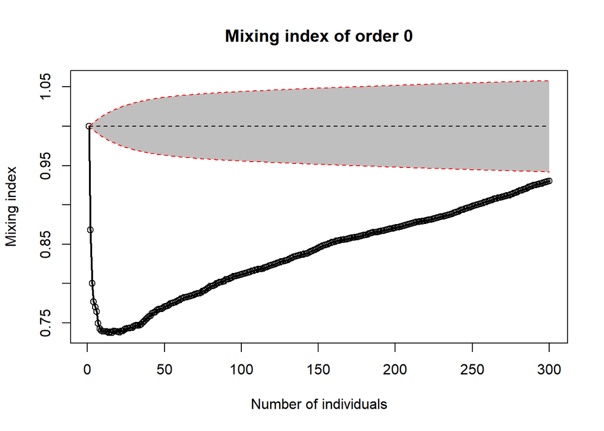

```r
plot(Montceau_accum, q = 0)
```

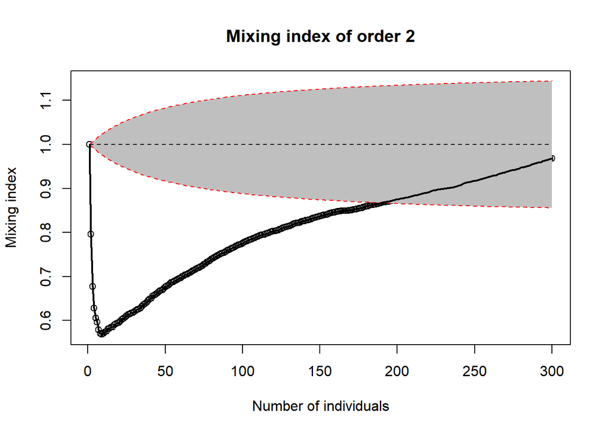

```r
plot(Montceau_accum, q = 2)
```

```r
MapPlot(Montceau_accum, Order = 0, NeighborHood = 10)
```

```
## [using ordinary kriging]
```

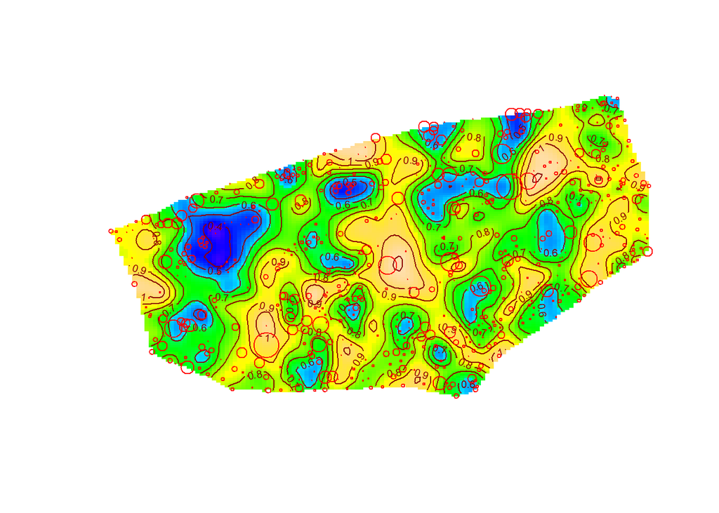

```r
plot(Montceau, which.marks = "PointWeight", col = "red",
    add = TRUE)
```

```r
Cygnes <- wmppp_adresse("ALLEE DES CYGNES", reverse = TRUE)
```

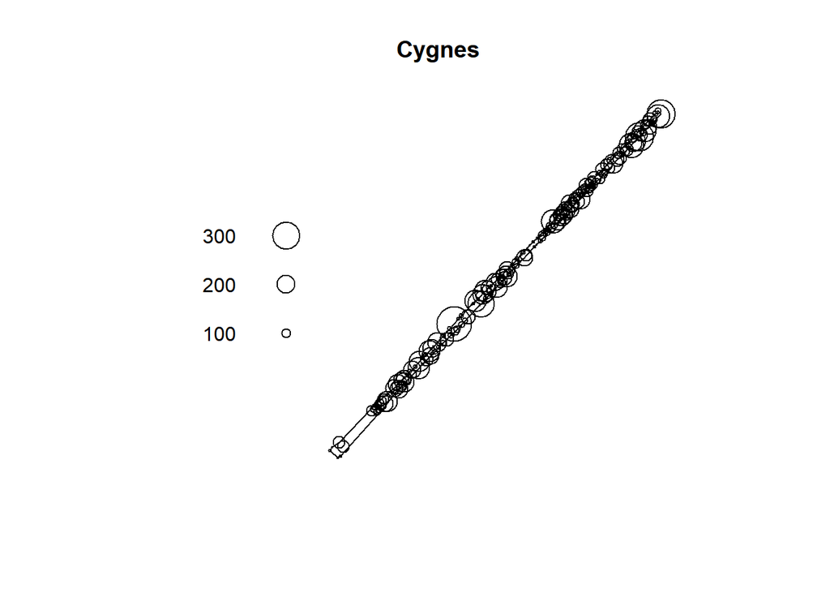

```r
plot(Cygnes, which.marks = "PointWeight")
```

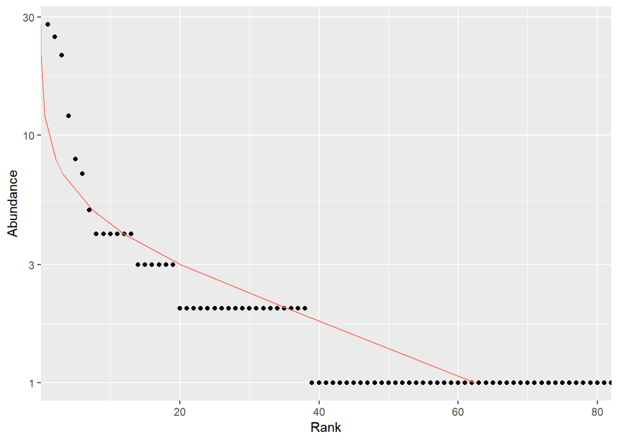

```r
autoplot(as.AbdVector(Cygnes), Distribution = "lnorm")
```

```r
Cygnes_accum <- Mixing(Cygnes, q.seq = c(0, 2), Individual = TRUE)
```

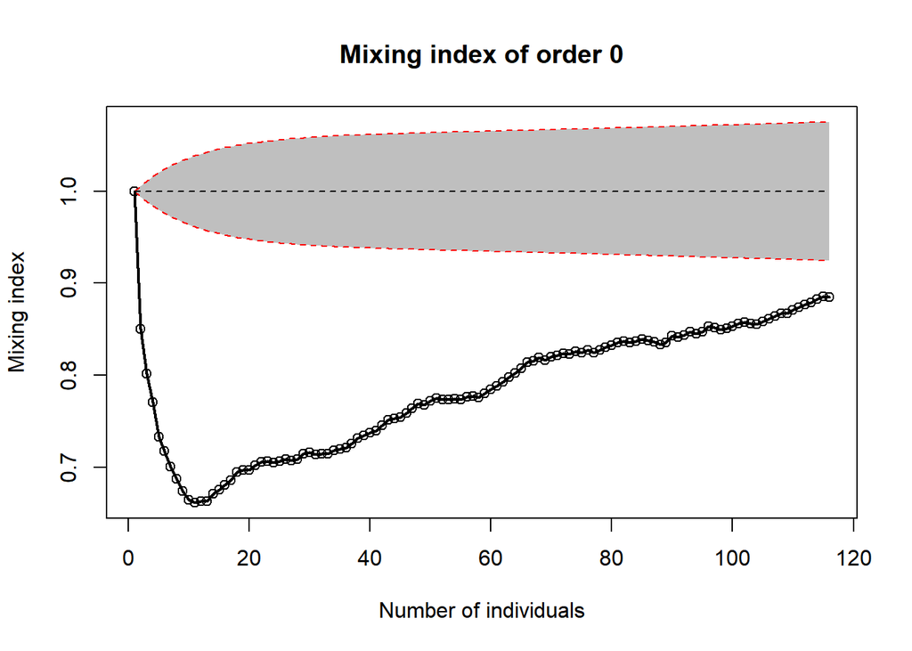

```r
plot(Cygnes_accum, q = 0)
```

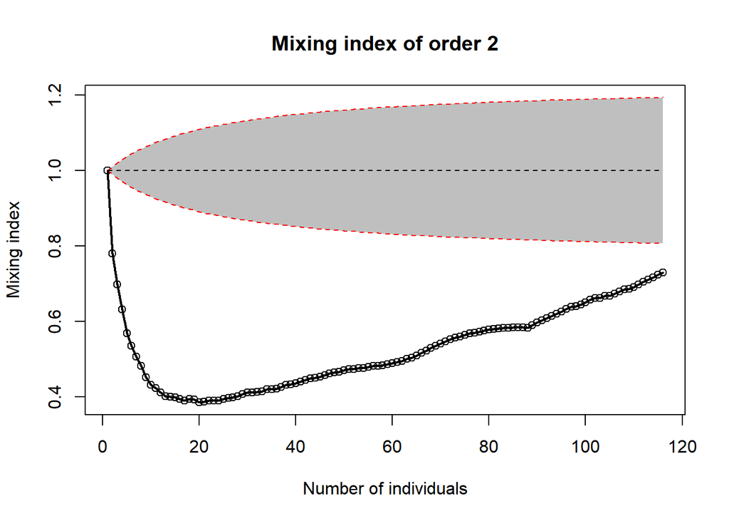

```r
plot(Cygnes_accum, q = 2)
```

```r
MapPlot(Cygnes_accum, Order = 0, NeighborHood = 10)
```

```
## [using ordinary kriging]
```

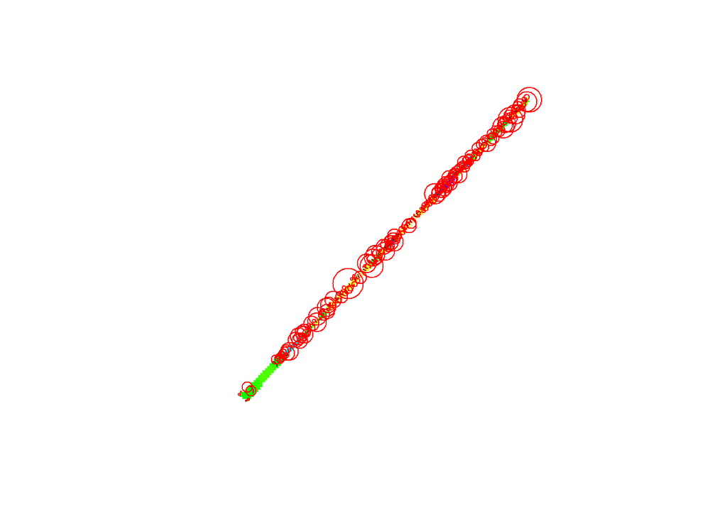

```r
plot(Cygnes, which.marks = "PointWeight", col = "red",
    add = TRUE)
```